# ModelBuilding_final

```python
pip install visualkeras
```

```
     ━━━━━━━━━━━━━━━━━━━━━━━━━━━━━━━━━━━━━━ 993.0/993.0 kB 13.1 MB/s eta 0:00:00
```

```python
#Importing Required Libraries.
import numpy as np
import pandas as pd
import tensorflow as tf
import visualkeras
from tensorflow import keras
from sklearn.metrics import mean_squared_error, mean_absolute_error, r2_score, accuracy_score,recall_score,precision_score,f1_score,ConfusionMatrixDisplay,confusion_matrix
from sklearn.linear_model import LinearRegression


# Load the Fashion MNIST dataset
# Locate the test and train csv files in local folder or use the path instead for the name
train_df = pd.read_csv('fashion-mnist_train.csv')
test_df = pd.read_csv('fashion-mnist_test.csv')

train_images = np.array(train_df.iloc[:, 1:])
test_images = np.array(test_df.iloc[:, 1:])
train_labels = np.array(train_df.iloc[:, 0])
test_labels = np.array(test_df.iloc[:, 0])

# Normalizing the pixel values to be between 0 and 1
train_images = train_images.reshape((-1, 28, 28, 1)) / 255.0
test_images = test_images.reshape((-1, 28, 28, 1)) / 255.0

# Convert the labels to one-hot encoded vectors
# train_labels = keras.utils.to_categorical(train_labels)
# test_labels = keras.utils.to_categorical(test_labels)
```

DISPLAYING THE FIRST 25 IMAGES OF THE TRAINING DATASET

[figure not shown]

```python
import matplotlib.pyplot as plt
class_names = ['T-shirt/top', 'Trouser', 'Pullover', 'Dress', 'Coat',
               'Sandal', 'Shirt', 'Sneaker', 'Bag', 'Ankle boot']

# Plot the images
plt.figure(figsize=(10,10))
for i in range(25):
    plt.subplot(5,5,i+1)
    plt.xticks([])
    plt.yticks([])
    plt.grid(False)
    plt.imshow(train_images[i], cmap=plt.cm.binary)

plt.show()
```

## **CONVOLUTION NEURAL NETWORK**

```python
#CONVOLUTION NEURAL NETWORK

model1 = keras.Sequential([
    keras.layers.Conv2D(32, (3,3), activation='relu', input_shape=(28,28,1)),

    keras.layers.Conv2D(64, (3,3), activation='relu'),
    keras.layers.MaxPooling2D((2,2)),
    keras.layers.Dropout((0.25)),
    keras.layers.Flatten(),
    keras.layers.Dense(128, activation='relu'),
    keras.layers.Dropout((0.5)),
    keras.layers.Dense(10, activation='softmax')
])
model1.summary()
```

```
Model: "sequential"
_________________________________________________________________
 Layer (type)                Output Shape              Param #
=================================================================
 conv2d (Conv2D)             (None, 26, 26, 32)        320

 conv2d_1 (Conv2D)           (None, 24, 24, 64)        18496

 max_pooling2d (MaxPooling2D  (None, 12, 12, 64)       0
 )

 dropout (Dropout)           (None, 12, 12, 64)        0

 flatten (Flatten)           (None, 9216)              0

 dense (Dense)               (None, 128)               1179776

 dropout_1 (Dropout)         (None, 128)               0

 dense_1 (Dense)             (None, 10)                1290

=================================================================
Total params: 1,199,882
Trainable params: 1,199,882
Non-trainable params: 0
_________________________________________________________________
```

```python
# Compile the model
model1.compile(optimizer=keras.optimizers.Adam(0.001),loss='sparse_categorical_crossentropy',metrics=['accuracy'])
# Train the model
history = model1.fit(train_images, train_labels, epochs=10, validation_data=(test_images, test_labels))

# Evaluate the model
test_loss, test_acc = model1.evaluate(test_images, test_labels)
print('CNN Model Test accuracy:', test_acc)

# Make predictions
predictions = model1.predict(test_images)
```

```
CNN Model Test accuracy: 0.9291999936103821
```

**Visualizing the CNN Model with visualkeras**

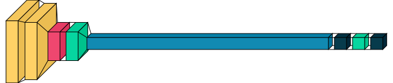

```python
#3D representation of CNN Model.
visualkeras.layered_view(model1)
```

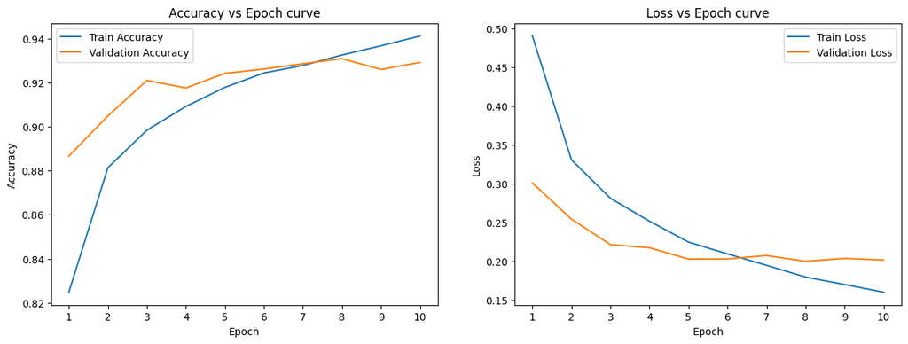

```python
#Plotting Line graph for accuracy agains epoch curve.
plt.figure(figsize=(15,5))
plt.subplot(1,2,1)
plt.plot([str(i) for i in range(1,11)],history.history['accuracy'],label="Train Accuracy")
plt.plot([str(i) for i in range(1,11)],history.history['val_accuracy'],label="Validation Accuracy")
plt.title("Accuracy vs Epoch curve")
plt.xlabel("Epoch")
plt.ylabel("Accuracy")
plt.legend()

#Plotting Line Graph for Loss agains epoch curve.
plt.subplot(1,2,2)
plt.plot([str(i) for i in range(1,11)],history.history['loss'],label="Train Loss")
plt.plot([str(i) for i in range(1,11)],history.history['val_loss'],label="Validation Loss")
plt.title("Loss vs Epoch curve")
plt.xlabel("Epoch")
plt.ylabel("Loss")
plt.legend()
plt.show()
```

```python
#Displaying Accuracy of the Model.
print("Test accuracy of CNN Model : {:.2f} %".format(model1.evaluate(test_images,test_labels)[1]*100))
#Displaying Loss of the model.
print("Test loss of CNN model : {:.4f}".format(model1.evaluate(test_images,test_labels)[0]))
```

```
Test accuracy of CNN Model : 92.92 %
Test loss of CNN model : 0.2014
```

```python
#Displaying Precision, Recall and F1 Score for CNN Model.
y_pred = model1.predict(test_images)
y_pred = np.argmax(y_pred,1)
print("Precision for CNN model : {:.2f} %".format(precision_score(test_labels,y_pred,average="macro")*100))
print("Recall for CNN model : {:.2f} %".format(recall_score(test_labels,y_pred,average="macro")*100))
print("F1 Score for CNN model : {:.2f} %".format(f1_score(test_labels,y_pred,average="macro")*100))
```

```
Precision for CNN model : 92.98 %
Recall for CNN model : 92.92 %
F1 Score for CNN model : 92.93 %
```

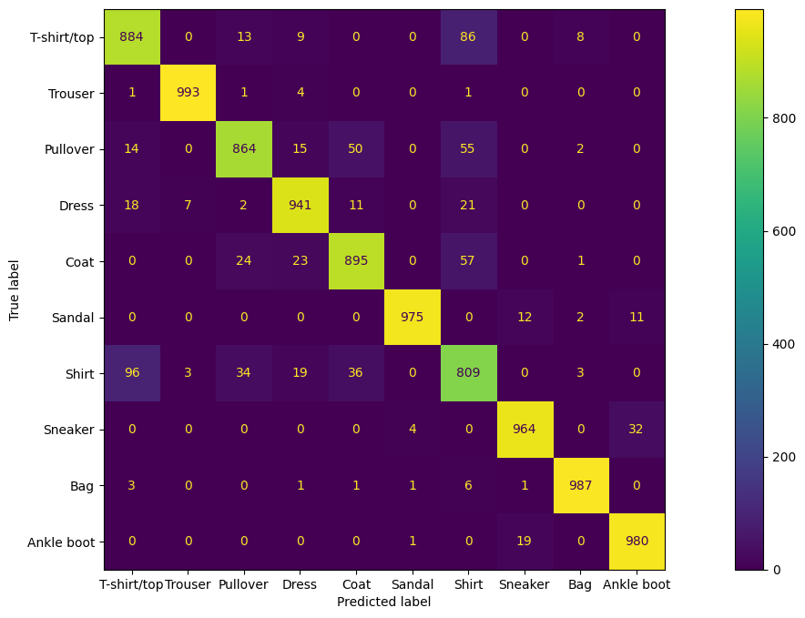

```python
#Plotting Confusion matrix
fig,ax = plt.subplots(figsize=(20,8))
cfm = confusion_matrix(test_labels,y_pred)
disp = ConfusionMatrixDisplay(cfm,display_labels=class_names)
disp.plot(ax=ax)
plt.show()
```

## **LINEAR REGRESSION MODEL**

```python
#LINEAR REGRESSION MODEL
train_images_lr = train_images.reshape((-1, 784))
test_images_lr = test_images.reshape((-1, 784))
model2 = LinearRegression()
model2.fit(train_images_lr,train_labels)
# lr_test_prediction = model2.predict(test_images_lr)
model2_prediction = model2.predict(test_images.reshape((-1, 28*28))).astype(int)
print("Linear Regression test accuracy:", accuracy_score(test_labels, model2_prediction)*100,"%")
```

```
Linear Regression test accuracy: 32.28 %
```

```python
#Displaying MSE, MAE and R-Squared value for LR model.
lr_test_prediction = model2.predict(test_images_lr)
mse_lr = mean_squared_error(test_labels,lr_test_prediction)
mae_lr = mean_absolute_error(test_labels, lr_test_prediction)
r2_lr = r2_score(test_labels, lr_test_prediction)
print("Mean squared error for Linear Regression Model :", mse_lr)
print("Mean absolute error for Linear Regression Model:",mae_lr)
print("Linear regression R-Squared:", r2_lr)
```

```
Mean squared error for Linear Regression Model : 1.9638568194939998
Mean absolute error for Linear Regression Model: 1.0140199090206359
Linear regression R-Squared: 0.7619567491522424
```

## **K-NEAREST NEIGHBOUR MODEL**

```python
#kNN MODEL
from sklearn.neighbors import KNeighborsClassifier
model3 = KNeighborsClassifier(n_neighbors=9)
#Train the model
train_images_knn = train_images.reshape((-1, 784))
test_images_knn = test_images.reshape((-1, 784))
model3.fit(train_images_knn, train_labels)
model3_prediction = model3.predict(test_images_knn)
#Printing the Prediction
print("K-Nearest Neighbors Classifier test accuracy:", accuracy_score(test_labels, model3_prediction)*100,"%")
```

```
K-Nearest Neighbors Classifier test accuracy: 85.61 %
```

```python
#Displaying MSE, MAE and R-Squared value for k-Nearest Neighbour model.
mse_knn = mean_squared_error(test_labels,model3_prediction)
mae_knn = mean_absolute_error(test_labels, model3_prediction)
r2_knn = r2_score(test_labels, model3_prediction)
print("Mean squared error for K-Nearest Neighbour Model :", mse_knn)
print("Mean absolute error for K-Nearest Neighbour Model:",mae_knn)
print("K-Nearest Neighbour R-Squared:", r2_knn)
```

```
Mean squared error for K-Nearest Neighbour Model : 1.9864
Mean absolute error for K-Nearest Neighbour Model: 0.4742
K-Nearest Neighbour R-Squared: 0.7592242424242424
```

## **DECISION TREE MODEL**

```python
#DECISION TREE MODEL
from sklearn.tree import DecisionTreeClassifier
model4 = DecisionTreeClassifier(random_state=35)
train_images_dt = train_images.reshape((-1, 784))
test_images_dt = test_images.reshape((-1, 784))
model4.fit(train_images_dt, train_labels)
model4_prediction = model4.predict(test_images.reshape((-1, 28*28))).astype(int)
print("Decision Tree Classifier test accuracy:", accuracy_score(test_labels, model4_prediction)*100,"%")
```

```
Decision Tree Classifier test accuracy: 79.84 %
```

```python
#Displaying MSE, MAE and R-Squared value for Decision Tree model.
dt_test_prediction = model4.predict(test_images_dt)
mse_dt = mean_squared_error(test_labels,dt_test_prediction)
mae_dt = mean_absolute_error(test_labels, dt_test_prediction)
r2_dt = r2_score(test_labels, dt_test_prediction)
print("Mean squared error for Decision Tree Model :", mse_dt)
print("Mean absolute error for Decision Tree Model Model:",mae_dt)
print("Decision Tree Model R-Squared:", r2_dt)
```

```
Mean squared error for Decision Tree Model : 2.6799
Mean absolute error for Decision Tree Model Model: 0.6455
Decision Tree Model R-Squared: 0.6751636363636364
```

```python
%%shell
jupyter nbconvert --to html /content/ModelBuilding_final.ipynb
```

```
[NbConvertApp] Converting notebook /content/ModelBuilding_final.ipynb to html
[NbConvertApp] Writing 850839 bytes to /content/ModelBuilding_final.html
```

Questions we're Trying to answer !

1. Which model has highest accuracy.

   CNN model has the highest accuracy with 92%
2. Which model has least accuracy.

   CNN model can learn hierarchical representation of images and capture increasingly complex feature as we go deep into the networks. It can learn high level concepts like sleeve length or collar type from raw pixel values, Which is difficult for other models to capture.
5. What would you do in the next iteration of this project.

   Since we know that CNN is performing bettor for Image processing we are planning to create a model to identify ancient scriptures, And do NLP analysis on it.
1. What have you learnt from this project.

   From this project, we have learnt to analyze different ML models to a dataset and evaluate its performance with Precision, Recall, Accuracy and F1 Score. We have learnt that every models acts differently for different datasets.